# R Notebook

# BE1-

**Meriem Tarqui - Mariem Naimi**

## Exercice1:

Variable à expliquer: Y= le prix de mise en vente

Variable explicative: X= surface

#### Visualisation de données:

```r
Immo = read.table(file = "immo.txt", header = TRUE)
head(Immo)
```

|  | m2 | prix |
| --- | --- | --- |
| 1 | 29 | 83 |
| 2 | 37 | 97 |
| 3 | 45 | 105 |
| 4 | 70 | 122 |
| 5 | 50 | 125 |
| 6 | 55 | 117 |

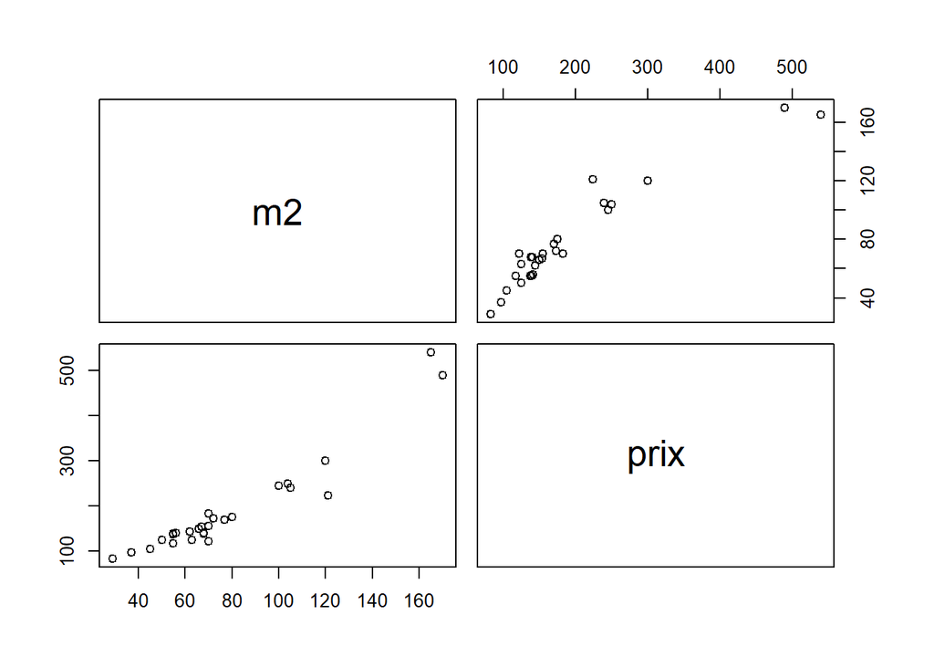

```r
pairs(Immo)
```

#### Question 1.a

Droite de la Regression

```r
mod1 = lm(prix~m2, data = Immo)
summary(mod1)
```

```
##
## Call:
## lm(formula = prix ~ m2, data = Immo)
##
## Residuals:
##     Min      1Q  Median      3Q     Max
## -92.347 -16.996  -2.367  18.578  92.470
##
## Coefficients:
##             Estimate Std. Error t value Pr(>|t|)
## (Intercept) -44.4093    16.0127  -2.773   0.0103 *
## m2            2.9815     0.1889  15.786 1.65e-14 ***
## ---
## Signif. codes:  0 '***' 0.001 '**' 0.01 '*' 0.05 '.' 0.1 ' ' 1
##
## Residual standard error: 33.11 on 25 degrees of freedom
## Multiple R-squared:  0.9088, Adjusted R-squared:  0.9052
## F-statistic: 249.2 on 1 and 25 DF,  p-value: 1.646e-14
```

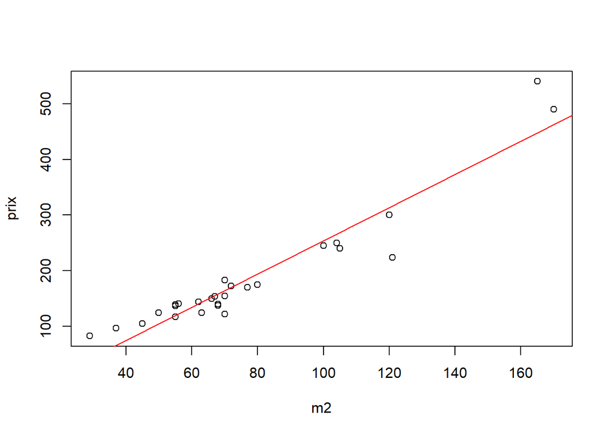

```r
plot(prix~m2, data = Immo)
abline(mod1$coefficients, col = 'red')
```

#### Question 1.b : $R^2$= 0.9 donc 90% de la variance est expliquée par le modèle

#### Question 1.c : Test de significativité

Hypothèse H0: $\beta_{i}$ =0 pour i = 1,2 (non linéarité)

C’est une statistique de Fischer de n-(p+1)=25 dégrés de liberté.

La p-value = 1.64e-14 <0.05, ainsi on rejette H0 => Ainsi il existe au moins un i tel que $\beta_{i}$ différent de 0. *Donc le modèle linéaire est à garder.*

#### Question 2 et 3: Prédiction et intervalles de confiance:

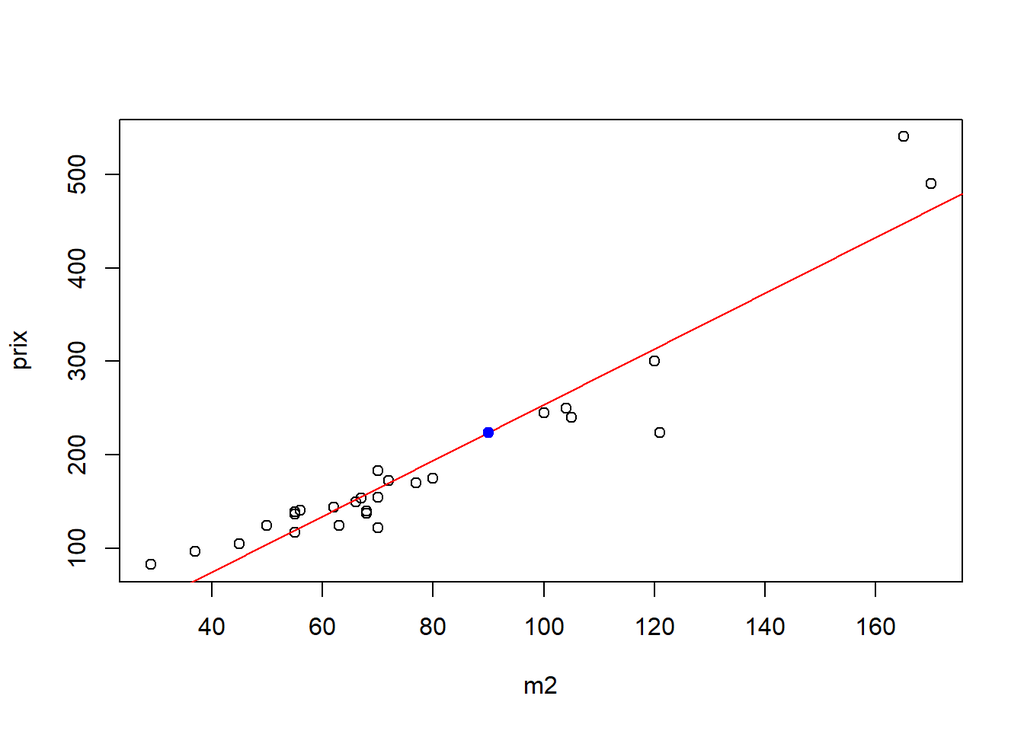

```r
nouvel_individu = data.frame(m2= 90)
prediction = predict(mod1, newdata = nouvel_individu)
plot(prix~m2, data = Immo)
abline(mod1$coefficients, col = 'red')
points(nouvel_individu$m2,prediction,col ="blue", pch = 19)
```

```r
#print(prediction)
```

On déduit que le prix prévu pour un appartement de 90m2 est 223.9215 Keuros (le point bleu sur le graphique).

```r
prediction_IC = data.frame(predict(mod1, newdata = nouvel_individu, interval = 'confidence', level = 0.95))
prediction_IC
```

|  | fit | lwr | upr |
| --- | --- | --- | --- |
| 1 | 223.9215 | 209.962 | 237.8809 |

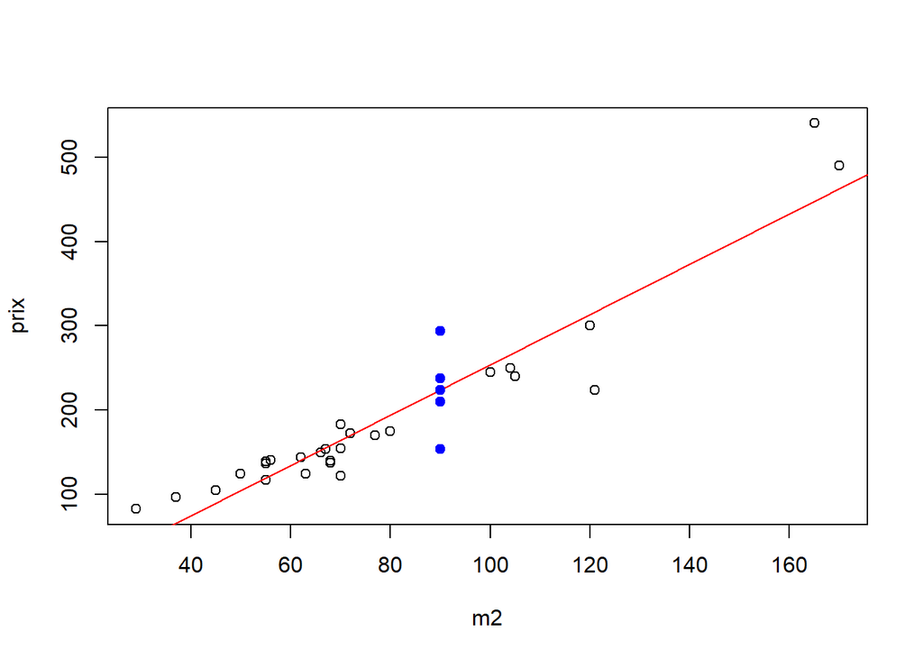

```r
plot(prix~m2, data = Immo)
abline(mod1$coefficients, col = 'red')
points(nouvel_individu$m2,prediction_IC$fit,col ="blue", pch = 19)
points(nouvel_individu$m2,prediction_IC$lwr,col ="blue", pch = 19)
points(nouvel_individu$m2,prediction_IC$upr,col ="blue", pch = 19)


prediction_IP = data.frame(predict(mod1, newdata = nouvel_individu, interval = 'prediction', level = 0.95))
points(nouvel_individu$m2,prediction_IP$lwr,col ="blue", pch = 19)
points(nouvel_individu$m2,prediction_IP$upr,col ="blue", pch = 19)
```

```r
prediction_IP
```

|  | fit | lwr | upr |
| --- | --- | --- | --- |
| 1 | 223.9215 | 154.3086 | 293.5343 |

Ainsi, l’intervalle de confiance pour ce prix à une incertitude de 95% est [209.962 , 237.8809] en Keuros.

Ensuite, l’intervalle de prédiction est [154.3086 , 293.5343], ce qui veut dire que c’est statistiquement acceptable de mettre en vente un appartement de 90m2 à 280Keuros pour un intervalle de prédiction à 95%.

#### Question 4: Etude de résidus et ajustement du modèle

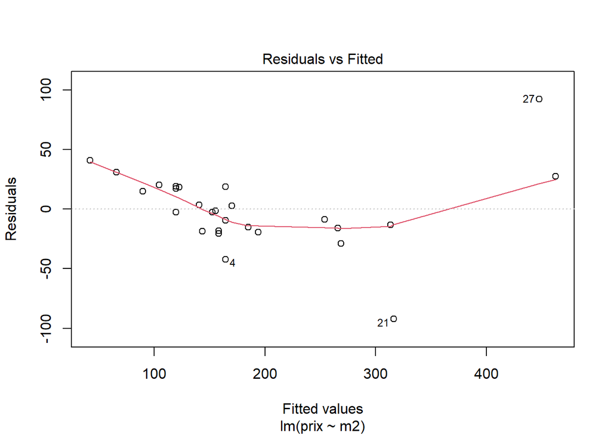

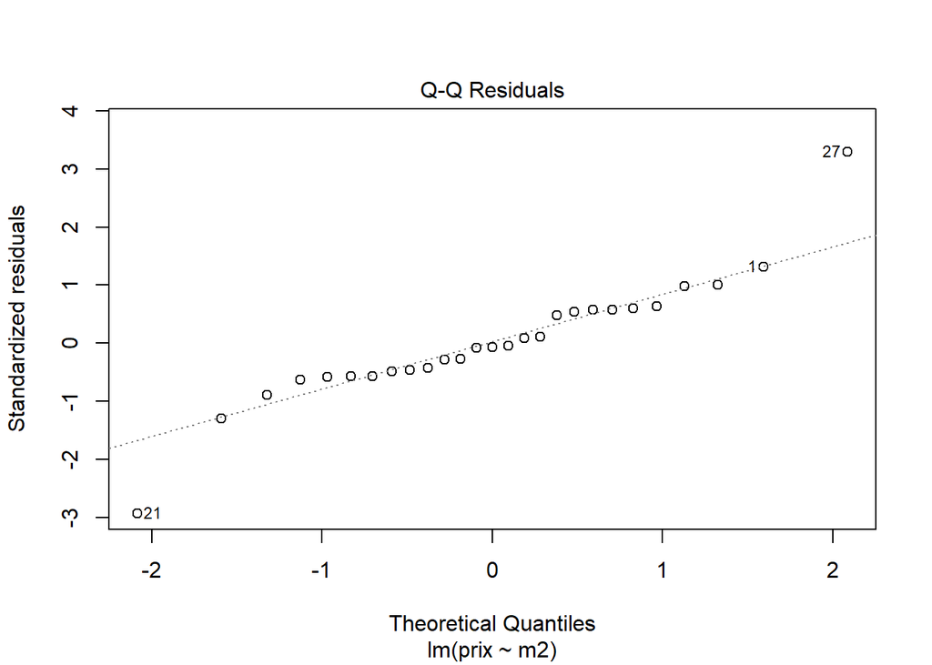

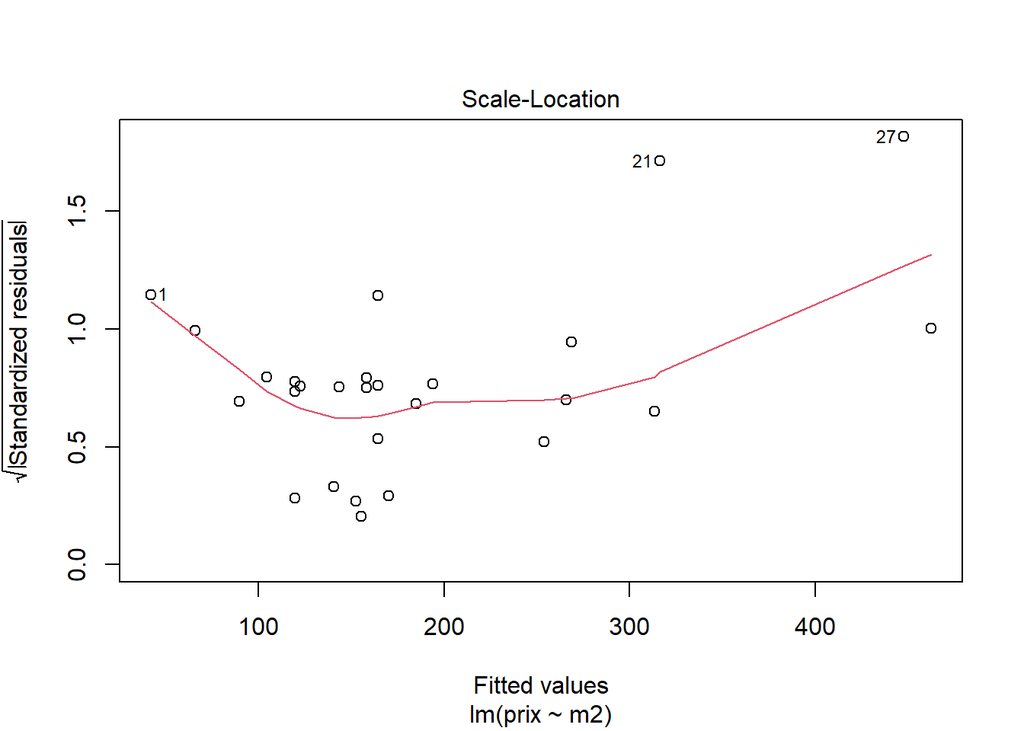

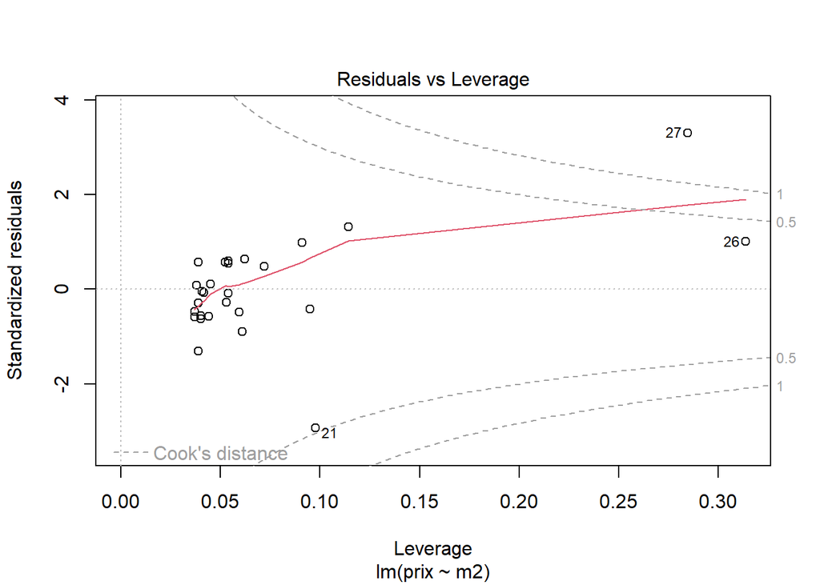

```r
plot(mod1)
```

Etude des résidus : on remarque sur le graphique Residuals vs Fitted, que les résidus prennnent des grandes valeurs (à peu près 50) et que la droite de tendance n’est pas plate (dans un modèle linéaire idéal les résidus sont à peu près nuls et sont indépendants des estimations). On remarque également que les résidus ne sont pas répartis unifromément par rapport à la courbe de tendance ce qui signifie qu’ils dépendent des estimations, ce qui remet en question la validité de ce modèle de régression linéaire.

```r
mod2 = lm(prix~m2+I(m2^2), data = Immo)
summary(mod2)
```

```
##
## Call:
## lm(formula = prix ~ m2 + I(m2^2), data = Immo)
##
## Residuals:
##     Min      1Q  Median      3Q     Max
## -73.053  -8.565   2.987  10.933  49.232
##
## Coefficients:
##              Estimate Std. Error t value Pr(>|t|)
## (Intercept) 92.663153  27.991692   3.310  0.00294 **
## m2          -0.300683   0.629388  -0.478  0.63716
## I(m2^2)      0.016445   0.003085   5.331  1.8e-05 ***
## ---
## Signif. codes:  0 '***' 0.001 '**' 0.01 '*' 0.05 '.' 0.1 ' ' 1
##
## Residual standard error: 22.87 on 24 degrees of freedom
## Multiple R-squared:  0.9583, Adjusted R-squared:  0.9548
## F-statistic: 275.4 on 2 and 24 DF,  p-value: < 2.2e-16
```

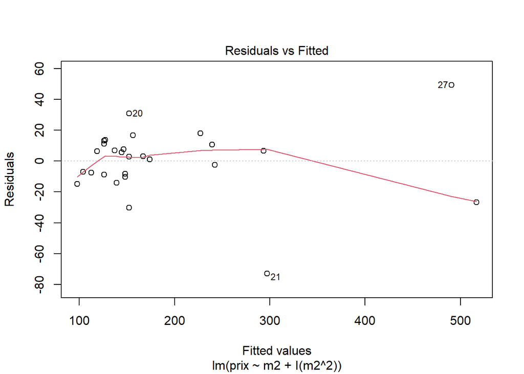

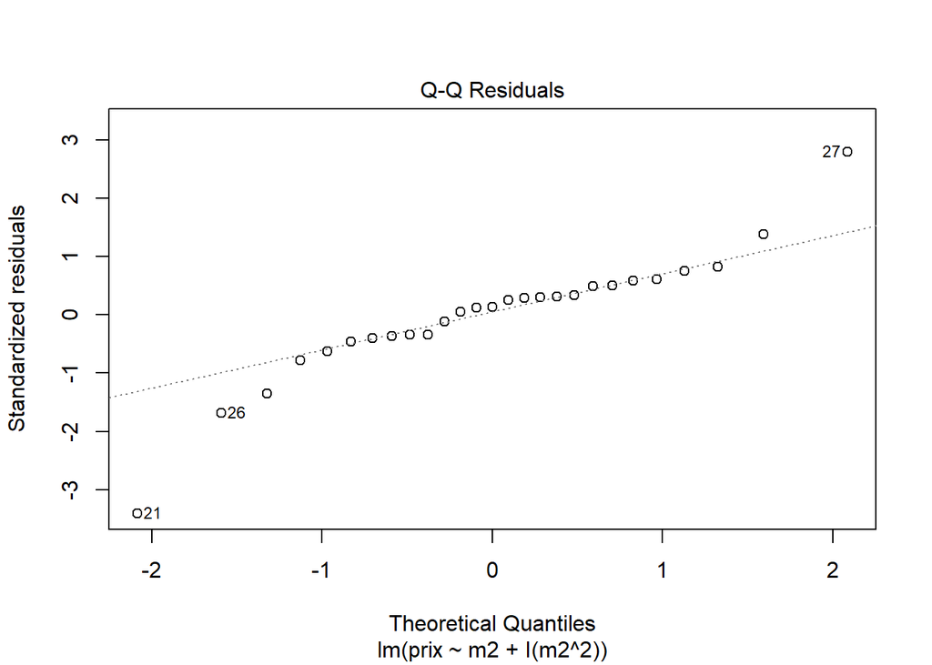

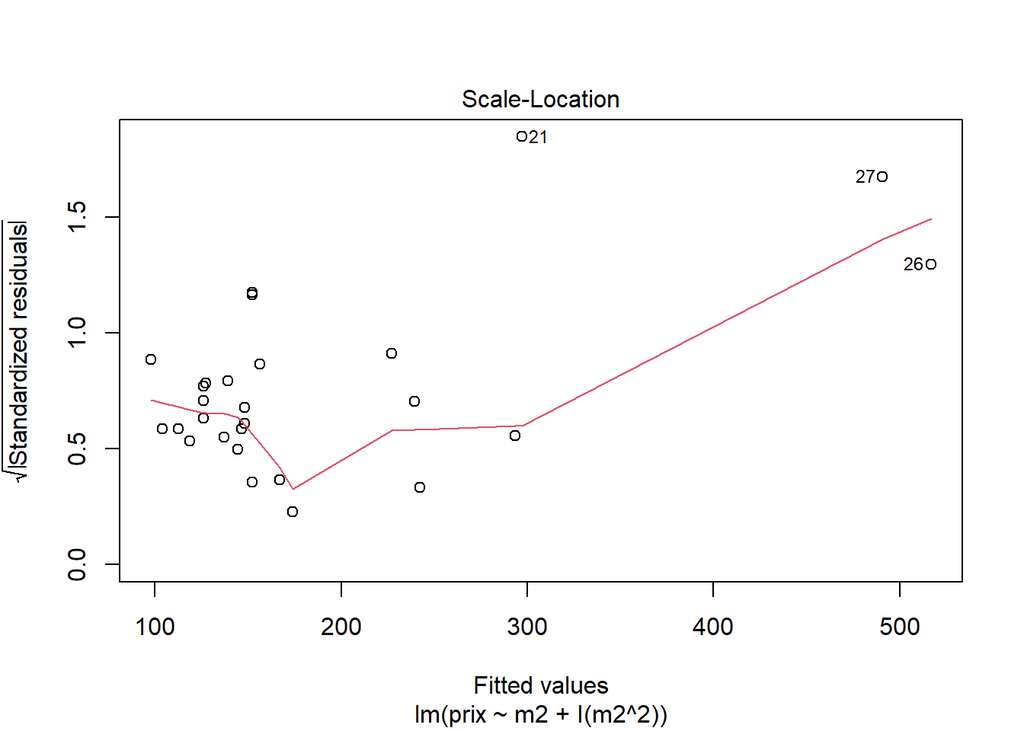

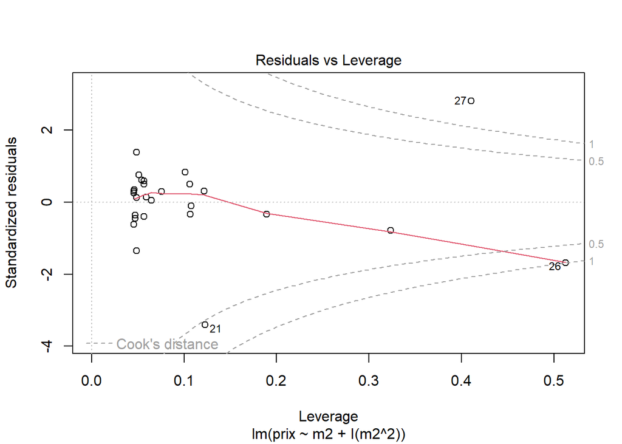

```r
plot(mod2)
```

Pour affiner le modèle de régression linéaire, on étudie le modèle suivant :

Y = $\beta{0} + \beta{1} X + \beta{2} X^2$

L’erreur standard résiduel R2 de ce nouveau modèle est supérieur au R2 du premier modèle (0.9088). En plus, en comparant les résidus, on s’aperçoit que les résidus du premier modèle sont élevés par rapport au nouveau modèle (entre -50 et 50 pour le premier, et -40 et 40 pour le deuxième pour la majorité des erreurs). On en déduit que ce modèle est meilleur que le premier.

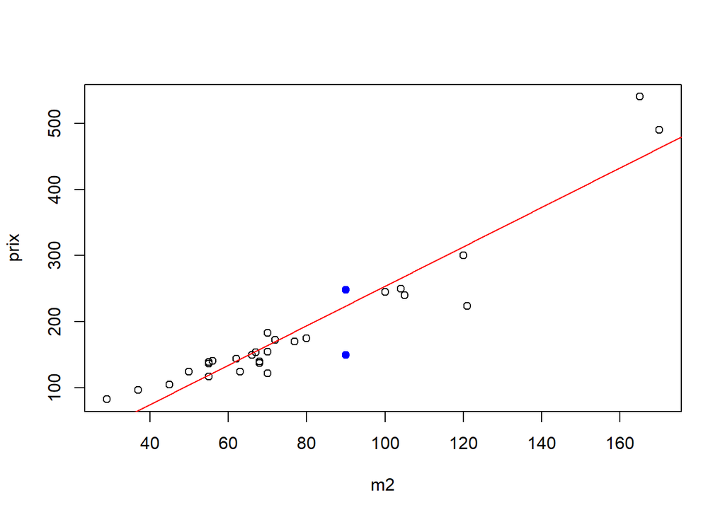

```r
plot(prix~m2, data = Immo)
abline(mod1$coefficients, col = 'red')
prediction_IP = data.frame(predict(mod2, newdata = nouvel_individu, interval = 'prediction', level = 0.95))
points(nouvel_individu$m2,prediction_IP$lwr,col ="blue", pch = 19)
points(nouvel_individu$m2,prediction_IP$upr,col ="blue", pch = 19)
```

```r
prediction_IP
```

|  | fit | lwr | upr |
| --- | --- | --- | --- |
| 1 | 198.8068 | 149.657 | 247.9566 |

Ainsi, l’intervalle di’ncertitude de prédiction pour un appartement de 90m2 a été réduit.

## Exercice2:

Les variables explicatives:  
— CRIM taux de criminalité par habitant — ZN proportion de terrains résidentiels — INDUS proportion de terrains industriels — CHAS 1 si ville en bordure de la rivière Charles 0 sinon — NOX concentration en oxydes d’azote — RM nombre moyen de pièces par logement — AGE proportion de logements construit avant 1940 — DIS distance du centre de Boston — RAD accessibilité aux autoroutes de contournement — TAX taux de l’impôt foncier — PTRATIO rapport élèves-enseignant par ville — LSTAT % de la population à faibles revenus

La variable à expliquer — class valeur du logement en 1000$

#### Question 1.

```r
House = read.table(file = "housing_new.txt", header = TRUE)
head(House)
```

|  | CRIM | ZN | INDUS | CHAS | NOX | RM | AGE | DIS | RAD | TAX | PTRATIO | LSTAT | class |
| --- | --- | --- | --- | --- | --- | --- | --- | --- | --- | --- | --- | --- | --- |
| 1 | 0.006 | 18 | 2.31 | 0 | 0.538 | 6.575 | 65.2 | 4.090 | 1 | 296 | 15.3 | 4.98 | 24.0 |
| 2 | 0.027 | 0 | 7.07 | 0 | 0.469 | 6.421 | 78.9 | 4.967 | 2 | 242 | 17.8 | 9.14 | 21.6 |
| 3 | 0.027 | 0 | 7.07 | 0 | 0.469 | 7.185 | 61.1 | 4.967 | 2 | 242 | 17.8 | 4.03 | 34.7 |
| 4 | 0.032 | 0 | 2.18 | 0 | 0.458 | 6.998 | 45.8 | 6.062 | 3 | 222 | 18.7 | 2.94 | 33.4 |
| 5 | 0.069 | 0 | 2.18 | 0 | 0.458 | 7.147 | 54.2 | 6.062 | 3 | 222 | 18.7 | 5.33 | 36.2 |
| 6 | 0.030 | 0 | 2.18 | 0 | 0.458 | 6.430 | 58.7 | 6.062 | 3 | 222 | 18.7 | 5.21 | 28.7 |

```r
mod3=lm(class~.,data=House )

summary(mod3)
```

```
##
## Call:
## lm(formula = class ~ ., data = House)
##
## Residuals:
##      Min       1Q   Median       3Q      Max
## -15.1299  -2.7673  -0.5816   1.9411  26.2520
##
## Coefficients:
##               Estimate Std. Error t value Pr(>|t|)
## (Intercept)  41.617992   4.936061   8.431 3.79e-16 ***
## CRIM         -0.121391   0.033000  -3.678 0.000260 ***
## ZN            0.046962   0.013879   3.384 0.000772 ***
## INDUS         0.013462   0.062145   0.217 0.828591
## CHAS          2.840102   0.870005   3.264 0.001173 **
## NOX         -18.758738   3.851359  -4.871 1.50e-06 ***
## RM            3.658127   0.420244   8.705  < 2e-16 ***
## AGE           0.003610   0.013329   0.271 0.786658
## DIS          -1.490767   0.201622  -7.394 6.17e-13 ***
## RAD           0.289397   0.066908   4.325 1.84e-05 ***
## TAX          -0.012681   0.003801  -3.336 0.000913 ***
## PTRATIO      -0.937562   0.132207  -7.092 4.62e-12 ***
## LSTAT        -0.552013   0.050659 -10.897  < 2e-16 ***
## ---
## Signif. codes:  0 '***' 0.001 '**' 0.01 '*' 0.05 '.' 0.1 ' ' 1
##
## Residual standard error: 4.798 on 493 degrees of freedom
## Multiple R-squared:  0.7343, Adjusted R-squared:  0.7278
## F-statistic: 113.5 on 12 and 493 DF,  p-value: < 2.2e-16
```

Le R2 = 0.7343 donc 73% de la variance est expliquée par le modèle

#### Question 2 : test de significativité

Hypothèse H0: $\beta_{i}$ =0 pour i = 1,2,..12 (test de non linéarité)

C’est une statistique de Fischer de n-(p+1)=493 dégrés de liberté. Sous H0, F = MSR/MSE suit la loi de fisher de n-(p+1)=493.

#### Question 3 .

Les variables significatives sont celles dont la p_value du test de student **est inférieure à 0.01.** Ainsi, les seuls variables qui ne sont pas significatives sont **INDUS et AGE.** Ainsi on est sûr que ces variables ne sont pas significatives.

#### Question 4.

Pour simplifier le modèle, on peut utiliser la méthode backward sur le test de student :

Dans cette méthode, on commence par le modèle complet avec toutes les variables Xi. Ensuite, à chaque pas on enlève la variable la moins significative, c’est-à-dire celle ayant la plus grande p_value. Le test s’arrête lorsque la p_value devient plus petite que 0.05.

On commence alors par enlever INDUS, et ensuite AGE.

```r
mod4=lm(class~. - INDUS ,data=House )

summary(mod4)
```

```
##
## Call:
## lm(formula = class ~ . - INDUS, data = House)
##
## Residuals:
##      Min       1Q   Median       3Q      Max
## -15.1262  -2.7488  -0.5903   1.9052  26.2603
##
## Coefficients:
##               Estimate Std. Error t value Pr(>|t|)
## (Intercept)  41.544474   4.919628   8.445 3.42e-16 ***
## CRIM         -0.121630   0.032950  -3.691 0.000248 ***
## ZN            0.046641   0.013786   3.383 0.000774 ***
## CHAS          2.859229   0.864678   3.307 0.001013 **
## NOX         -18.535685   3.707581  -4.999 8.00e-07 ***
## RM            3.650026   0.418173   8.729  < 2e-16 ***
## AGE           0.003607   0.013317   0.271 0.786627
## DIS          -1.499963   0.196912  -7.617 1.33e-13 ***
## RAD           0.285385   0.064230   4.443 1.10e-05 ***
## TAX          -0.012320   0.003411  -3.611 0.000336 ***
## PTRATIO      -0.933869   0.130977  -7.130 3.58e-12 ***
## LSTAT        -0.551109   0.050438 -10.927  < 2e-16 ***
## ---
## Signif. codes:  0 '***' 0.001 '**' 0.01 '*' 0.05 '.' 0.1 ' ' 1
##
## Residual standard error: 4.793 on 494 degrees of freedom
## Multiple R-squared:  0.7343, Adjusted R-squared:  0.7284
## F-statistic: 124.1 on 11 and 494 DF,  p-value: < 2.2e-16
```

```r
mod5=lm(class~. - INDUS-AGE ,data=House )

summary(mod5)
```

```
##
## Call:
## lm(formula = class ~ . - INDUS - AGE, data = House)
##
## Residuals:
##      Min       1Q   Median       3Q      Max
## -15.1809  -2.7623  -0.6239   1.8454  26.3913
##
## Coefficients:
##               Estimate Std. Error t value Pr(>|t|)
## (Intercept)  41.452529   4.903305   8.454 3.17e-16 ***
## CRIM         -0.121667   0.032919  -3.696 0.000244 ***
## ZN            0.046190   0.013673   3.378 0.000787 ***
## CHAS          2.871969   0.862589   3.329 0.000935 ***
## NOX         -18.263334   3.565266  -5.123 4.33e-07 ***
## RM            3.672962   0.409125   8.978  < 2e-16 ***
## DIS          -1.515957   0.187672  -8.078 5.07e-15 ***
## RAD           0.283927   0.063945   4.440 1.11e-05 ***
## TAX          -0.012291   0.003407  -3.608 0.000340 ***
## PTRATIO      -0.930993   0.130423  -7.138 3.39e-12 ***
## LSTAT        -0.546504   0.047442 -11.519  < 2e-16 ***
## ---
## Signif. codes:  0 '***' 0.001 '**' 0.01 '*' 0.05 '.' 0.1 ' ' 1
##
## Residual standard error: 4.789 on 495 degrees of freedom
## Multiple R-squared:  0.7342, Adjusted R-squared:  0.7289
## F-statistic: 136.8 on 10 and 495 DF,  p-value: < 2.2e-16
```

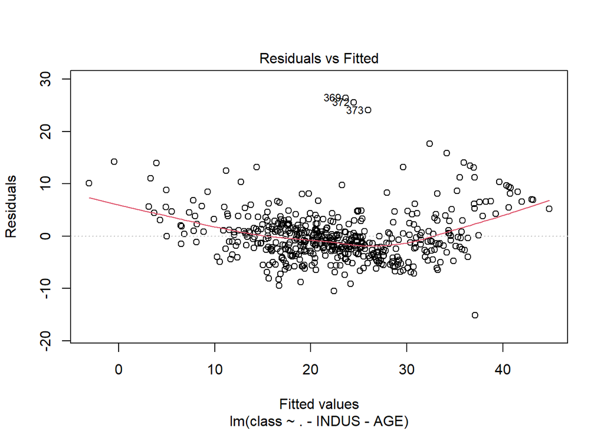

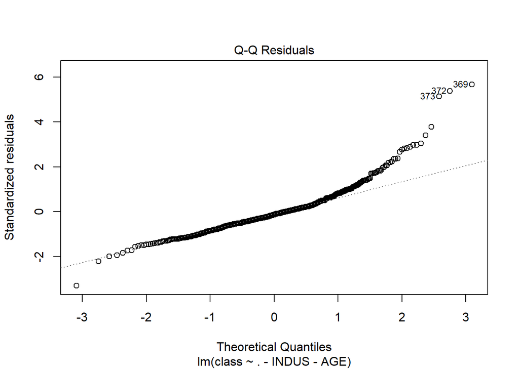

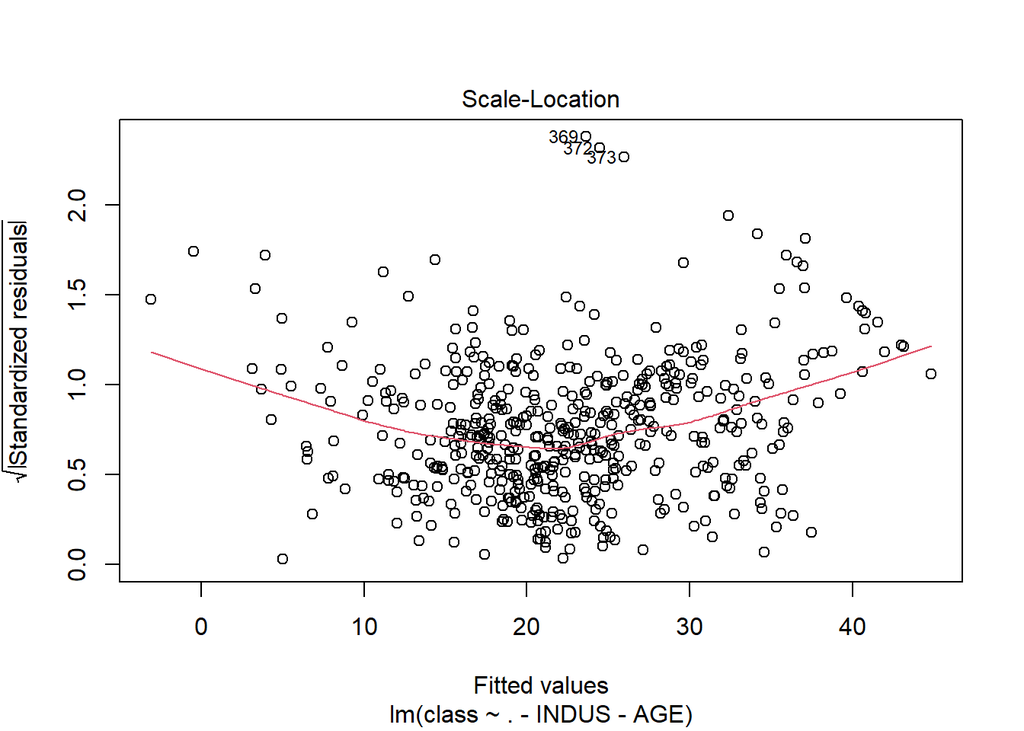

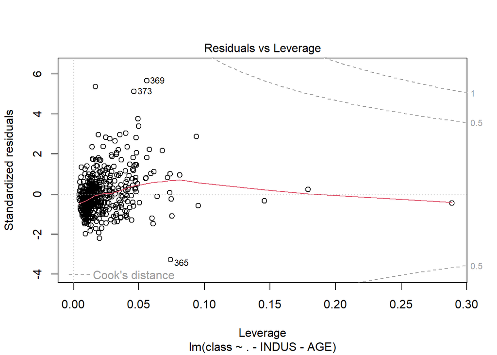

```r
plot(mod5)
```

#### Question 5 .

On remarque que l’erreur R2 a peu près gardé la même valeur du modèle initial. En plus, en regardant les graphiques sur les résidus, variance, effet de levier et Q-Q plot, on s’aperçoit que les résidus n’ont pas été réduits et que le modèle n’a pas été amélioré. On en déduit que ce nouveau modèle n’est pas satisfaisant.

#### Question 6:

On conclut de la question précédente que la sélection des variables en utilisant le test de student ne permet pas d’améliorer le modèle.

On propose alors d’utiliser les critères AIC et BIC

Critère d’Akaike : AIC = −2 ∗ logL + 2(p + 1)

Critère Bayesien : BIC = −2 ∗ logL + ln(n)(p + 1)

Avec: L la vraisemblance

p= 12

n= 506

Dans cette méthode , l’algorithme démarre cette fois du modèle complet. A chaque l’étape, la variable associée la plus grande diminution de l’AIC est éliminée du modèle. La procédure s’arrête lorsque quelque soit la variable à retirer le critère AIC (resp. BIC) remonte.

```r
slm_AIC <- step(mod3,direction= "backward",k = 2, trace= FALSE)
slm_BIC <- step(mod3,direction= "backward",k = log(nrow(House)), trace= FALSE)
coef(slm_AIC)
```

```
##  (Intercept)         CRIM           ZN         CHAS          NOX           RM
##  41.45252912  -0.12166729   0.04618983   2.87196885 -18.26333364   3.67296197
##          DIS          RAD          TAX      PTRATIO        LSTAT
##  -1.51595743   0.28392720  -0.01229089  -0.93099301  -0.54650445
```

```r
coef(slm_BIC)
```

```
##  (Intercept)         CRIM           ZN         CHAS          NOX           RM
##  41.45252912  -0.12166729   0.04618983   2.87196885 -18.26333364   3.67296197
##          DIS          RAD          TAX      PTRATIO        LSTAT
##  -1.51595743   0.28392720  -0.01229089  -0.93099301  -0.54650445
```

On remarque que les deux méthodes AIC et BIC élliminent les deux variables elliminés par la méthode de Student faite auparavant (INDUS et AGE).

On propose alors un nouveau modèle qui ne prend en compte que les variables significatives et leur carrés :

```r
mod4=lm(class~ CRIM+ZN+CHAS+NOX+RM+DIS+RAD+TAX+PTRATIO+LSTAT+I(CRIM^2)+I(ZN^2)+I(CHAS^2)+I(NOX^2)+I(RM^2)+I(DIS^2)+I(RAD^2)+I(TAX^2)+I(PTRATIO^2)+I(LSTAT^2),data=House )

summary(mod4)
```

```
##
## Call:
## lm(formula = class ~ CRIM + ZN + CHAS + NOX + RM + DIS + RAD +
##     TAX + PTRATIO + LSTAT + I(CRIM^2) + I(ZN^2) + I(CHAS^2) +
##     I(NOX^2) + I(RM^2) + I(DIS^2) + I(RAD^2) + I(TAX^2) + I(PTRATIO^2) +
##     I(LSTAT^2), data = House)
##
## Residuals:
##      Min       1Q   Median       3Q      Max
## -25.6781  -2.1877  -0.1878   1.7038  25.4814
##
## Coefficients: (1 not defined because of singularities)
##                Estimate Std. Error t value Pr(>|t|)
## (Intercept)   1.675e+02  2.089e+01   8.018 8.10e-15 ***
## CRIM         -4.210e-01  8.338e-02  -5.049 6.29e-07 ***
## ZN           -5.480e-02  3.120e-02  -1.756 0.079634 .
## CHAS          2.653e+00  7.115e-01   3.729 0.000215 ***
## NOX          -1.859e+01  2.418e+01  -0.769 0.442345
## RM           -1.993e+01  2.770e+00  -7.196 2.37e-12 ***
## DIS          -2.837e+00  5.271e-01  -5.383 1.14e-07 ***
## RAD           5.788e-01  2.097e-01   2.760 0.005991 **
## TAX          -3.364e-02  1.170e-02  -2.874 0.004226 **
## PTRATIO      -5.320e+00  1.665e+00  -3.195 0.001489 **
## LSTAT        -1.353e+00  1.196e-01 -11.316  < 2e-16 ***
## I(CRIM^2)     3.433e-03  1.083e-03   3.170 0.001622 **
## I(ZN^2)       7.120e-04  3.428e-04   2.077 0.038287 *
## I(CHAS^2)            NA         NA      NA       NA
## I(NOX^2)     -3.348e+00  1.777e+01  -0.188 0.850655
## I(RM^2)       1.790e+00  2.168e-01   8.256 1.43e-15 ***
## I(DIS^2)      1.594e-01  4.358e-02   3.658 0.000282 ***
## I(RAD^2)     -1.026e-02  8.314e-03  -1.234 0.217821
## I(TAX^2)      2.745e-05  1.469e-05   1.869 0.062239 .
## I(PTRATIO^2)  1.275e-01  4.709e-02   2.707 0.007020 **
## I(LSTAT^2)    2.337e-02  3.323e-03   7.032 6.96e-12 ***
## ---
## Signif. codes:  0 '***' 0.001 '**' 0.01 '*' 0.05 '.' 0.1 ' ' 1
##
## Residual standard error: 3.898 on 486 degrees of freedom
## Multiple R-squared:  0.8272, Adjusted R-squared:  0.8204
## F-statistic: 122.4 on 19 and 486 DF,  p-value: < 2.2e-16
```

On remarque que effectivement ce modèle est meileur, puisqu’il a un R2 plus élevé (0.8272).